# Missing-Data Treatments for PennDOT Crash Data: MAR vs. MNAR

**Goal.** Starting from two versions of the same 1,000 Pennsylvania crash records, one with values **Missing At Random (MAR)** and one with values **Missing Not At Random (MNAR)**, we:

1. profile every variable (histograms plus a data-quality check of what is missing),
2. check for outliers,
3. apply three missing-data treatments: **mean imputation**, **median imputation** and **complete-case removal**,
4. compare original and treated distributions side by side,
5. fit a **logistic regression** for `FATAL_OR_SUSP_SERIOUS_INJ` on every dataset and compare accuracy, F1 and **bias**.

| Variable | Meaning | Type |
| --- | --- | --- |
| `SPEEDING` | At least one vehicle was speeding | 0/1 |
| `WET_ROAD` | Wet-road indicator | 0/1 |
| `YOUNG_DRIVER` | At least one driver aged 16–20 | 0/1 |
| `HOUR_OF_DAY` | Hour the crash occurred (0–23) | integer |
| `PERSON_COUNT` | Total people involved | count |
| **`FATAL_OR_SUSP_SERIOUS_INJ`** (target) | At least one person killed or suspected serious injury | 0/1 |

**How to read the colors throughout:** ■ Original (untreated) · ■ Mean imputation · ■ Median imputation · ■ Complete case · **■ Reference (best-available truth)**

```python
import warnings
from pathlib import Path

import numpy as np
import pandas as pd
import matplotlib.pyplot as plt
import matplotlib.ticker as mtick
import seaborn as sns
import plotly.graph_objects as go
import plotly.io as pio
pio.renderers.default = "plotly_mimetype+notebook_connected"  # interactive in Jupyter and in exported HTML
from plotly.subplots import make_subplots
import statsmodels.api as sm
from sklearn.linear_model import LogisticRegression
from sklearn.model_selection import RepeatedStratifiedKFold, cross_validate
from sklearn.pipeline import make_pipeline
from sklearn.preprocessing import StandardScaler
from sklearn.metrics import accuracy_score, f1_score, recall_score, precision_score, roc_auc_score

from sklearn.exceptions import UndefinedMetricWarning
warnings.filterwarnings("ignore", category=FutureWarning)
warnings.filterwarnings("ignore", category=UndefinedMetricWarning)
pd.set_option("display.precision", 3)

TARGET = "FATAL_OR_SUSP_SERIOUS_INJ"
PREDICTORS = ["SPEEDING", "WET_ROAD", "YOUNG_DRIVER", "HOUR_OF_DAY", "PERSON_COUNT"]
COLS = PREDICTORS + [TARGET]
BINARY = ["SPEEDING", "WET_ROAD", "YOUNG_DRIVER", TARGET]
MECHS = ["MAR", "MNAR"]
TREATMENTS = ["Original", "Mean", "Median", "Complete case"]

# One color per treatment, used in every chart (validated for color-vision deficiency)
COLORS = {"Original": "#8a8986", "Mean": "#2a78d6", "Median": "#eb6834",
          "Complete case": "#1baf7a", "Reference": "#0b0b0b"}
MISSING_COLOR = "#d6d5d0"

sns.set_theme(style="whitegrid", context="notebook")
plt.rcParams.update({
    "axes.spines.top": False, "axes.spines.right": False,
    "axes.edgecolor": "#b5b4ae", "grid.color": "#ebeae6", "grid.linewidth": 0.8,
    "axes.titleweight": "semibold", "figure.dpi": 110, "font.size": 10,
})

DATA_DIR = Path(".")
OUT_DIR = Path("treated_datasets"); OUT_DIR.mkdir(exist_ok=True)
```

## 1. Load the data

The two files use slightly different column names (`HOUR` in MAR vs. `HOUR_OF_DAY` in MNAR, plus `Person count`), so we harmonize them first. Also note: the worksheet inside `MNAR_ex1.xls` is named `MCAR_ex1`. The file name and the assignment both say MNAR, and the missingness pattern below confirms it is **not** completely at random.

```python
def load(path):
    df = pd.read_excel(DATA_DIR / path)
    df = df.rename(columns={"HOUR": "HOUR_OF_DAY", "Person count": "PERSON_COUNT"})
    return df[COLS]

raw = {"MAR": load("MAR_ex1.xls"), "MNAR": load("MNAR_ex1.xls")}
for m, df in raw.items():
    print(f"{m}: {df.shape[0]:,} rows x {df.shape[1]} columns  (sheet: {pd.ExcelFile(DATA_DIR / f'{m}_ex1.xls').sheet_names[0]})")
raw["MAR"].head()
```

```
MAR: 1,000 rows x 6 columns  (sheet: MAR_ex1)
MNAR: 1,000 rows x 6 columns  (sheet: MCAR_ex1)
```

|  | SPEEDING | WET_ROAD | YOUNG_DRIVER | HOUR_OF_DAY | PERSON_COUNT | FATAL_OR_SUSP_SERIOUS_INJ |
| --- | --- | --- | --- | --- | --- | --- |
| 0 | 0 | 0.0 | 0.0 | 18 | 3.0 | 0 |
| 1 | 0 | 0.0 | 0.0 | 18 | 3.0 | 0 |
| 2 | 0 | NaN | 1.0 | 12 | 1.0 | 0 |
| 3 | 1 | 0.0 | 0.0 | 10 | NaN | 0 |
| 4 | 0 | NaN | NaN | 8 | 4.0 | 0 |

### 1a. Building a reference ("best-available truth") dataset

To say which treatment is **less biased**, we need the real values that are hidden behind the gaps. We can get them because of how the files relate:

- `MAR_ex1.xls`, `MNAR_ex1.xls` and the first 1,000 rows of the full extract `features.xls` are **the same 1,000 crashes in the same row order**.
- MAR and MNAR hide **different** cells, and `features.xls` has its own, different gaps. A value that is missing in one file is often present in another.

We build the reference in two steps. **The source files are never modified**; everything happens in memory in a new table called `reference`.

**Step 1 — Combine the three files.** For each cell, take the value from whichever file has it. This is only valid if the files never contradict each other, which is checked first.

```python
features_full = pd.read_excel(DATA_DIR / "features.xls").dropna(how="all").reset_index(drop=True).iloc[:1000]
features = features_full[COLS]

# Validity check: wherever two files both have a value, it must be the same value
for a_name, b_name, a, b in [("MAR", "MNAR", raw["MAR"], raw["MNAR"]),
                             ("MAR", "features", raw["MAR"], features),
                             ("MNAR", "features", raw["MNAR"], features)]:
    both = a.notna() & b.notna()
    print(f"{a_name:>4} vs {b_name:<8}: {int(((a != b) & both).sum().sum())} disagreeing cells "
          f"out of {int(both.sum().sum()):,} cells observed in both")

recon = raw["MAR"].fillna(raw["MNAR"]).fillna(features)
print("\nCells still unknown after combining the 3 files:", recon.isna().sum()[lambda s: s > 0].to_dict())
```

```
 MAR vs MNAR    : 0 disagreeing cells out of 5,172 cells observed in both
 MAR vs features: 0 disagreeing cells out of 5,547 cells observed in both
MNAR vs features: 0 disagreeing cells out of 5,172 cells observed in both

Cells still unknown after combining the 3 files: {'WET_ROAD': 44, 'YOUNG_DRIVER': 49}
```

The files agree on every shared cell, so combining them is safe. That recovers every value except **44 `WET_ROAD`** and **49 `YOUNG_DRIVER`** cells, which are blank in all three files.

**Step 2: derive the last 93 cells from related source fields.** `features.xls` contains the fields these flags are based on, and those fields have no gaps. Using the PennDOT *Crash Data Dictionary* (`Crash_Data_Dictionary_2026.pdf`):

| Flag | Dictionary definition | Source field(s) | Derivation rule |
| --- | --- | --- | --- |
| `WET_ROAD` | "Wet Road Indicator" (0 = No, 1 = Yes) | `ROAD_CONDITION` (roadway surface condition code) | **1 if `ROAD_CONDITION` is 08 or 09, else 0** |
| `YOUNG_DRIVER` | "The crash involved at least 1 driver age 16–20" | `DRIVER_COUNT_16YR` … `DRIVER_COUNT_20YR` ("total number of N-year-old drivers") | **1 if any of the five counts > 0, else 0** |

`ROAD_CONDITION` codes from the dictionary: 01 Dry · 02 Ice/Frost · 03 Mud, Dirt, Gravel · 04 Oil · 05 Sand · 06 Slush · 07 Snow · **08 Water (Standing or Moving)** · **09 Wet** · 22 Mud, Sand, Dirt, Oil (expired) · 98 Other · 99 Unknown.

**How each rule is justified**

- **`YOUNG_DRIVER`** follows directly from the dictionary: "at least one driver aged 16–20" is the same as "the count of drivers aged 16–20 is above zero".
- **`WET_ROAD`**: the dictionary does not list which codes set the flag, so the rule was **learned from the data**. In every crash where both are known, `WET_ROAD = 1` for codes 08 and 09 and `WET_ROAD = 0` for every other code (table below). Snow (07), slush (06) and ice (02) are *not* counted as wet.

The tables below test each rule against every cell where the true flag is known.

```python
WET_CODES = [8, 9]   # 08 = Water (standing or moving), 09 = Wet
YOUNG_COUNT_COLS = [f"DRIVER_COUNT_{age}YR" for age in range(16, 21)]
ROAD_LABELS = {1: "01 Dry", 2: "02 Ice/Frost", 3: "03 Mud, Dirt, Gravel", 4: "04 Oil", 5: "05 Sand", 6: "06 Slush",
               7: "07 Snow", 8: "08 Water", 9: "09 Wet", 22: "22 Mud/Sand/Dirt/Oil", 98: "98 Other", 99: "99 Unknown"}

derived = pd.DataFrame({
    "WET_ROAD": features_full["ROAD_CONDITION"].isin(WET_CODES).astype(float),
    "YOUNG_DRIVER": (features_full[YOUNG_COUNT_COLS].sum(axis=1) > 0).astype(float)})

# Evidence 1: recorded WET_ROAD flag by road-surface code (known cells only)
known = recon["WET_ROAD"].notna()
wet_check = pd.crosstab(features_full.loc[known, "ROAD_CONDITION"].map(ROAD_LABELS),
                        recon.loc[known, "WET_ROAD"].map({0: "WET_ROAD = 0", 1: "WET_ROAD = 1"}))
wet_check["Rule gives"] = [int(int(lbl[:2]) in WET_CODES) for lbl in wet_check.index]
display(wet_check.style.set_caption("Recorded WET_ROAD flag by ROAD_CONDITION code (cells where the flag is known)"))

# Evidence 2: recorded YOUNG_DRIVER flag vs. "any driver aged 16-20" (known cells only)
known = recon["YOUNG_DRIVER"].notna()
yd_check = pd.crosstab(derived.loc[known, "YOUNG_DRIVER"].map({0: "Rule: no driver 16-20", 1: "Rule: driver 16-20 present"}),
                       recon.loc[known, "YOUNG_DRIVER"].map({0: "YOUNG_DRIVER = 0", 1: "YOUNG_DRIVER = 1"}))
display(yd_check.style.set_caption("Recorded YOUNG_DRIVER flag vs. the driver-age-count rule (cells where the flag is known)"))

rows = []
for c in derived:
    known = recon[c].notna(); gap = recon[c].isna()
    rows.append({"Flag": c, "Known cells tested": int(known.sum()),
                 "Rule agrees": int((derived.loc[known, c] == recon.loc[known, c]).sum()),
                 "Agreement": (derived.loc[known, c] == recon.loc[known, c]).mean(),
                 "Cells filled by rule": int(gap.sum()), "…filled as 1": int(derived.loc[gap, c].sum())})
display(pd.DataFrame(rows).set_index("Flag").style.format({"Agreement": "{:.1%}"}).set_caption("Rule validation summary"))

conflicts = recon["YOUNG_DRIVER"].notna() & (derived["YOUNG_DRIVER"] != recon["YOUNG_DRIVER"])
print("Rows where YOUNG_DRIVER = 1 but all five 16–20 driver counts are 0:", conflicts[conflicts].index.tolist())

recon[["WET_ROAD", "YOUNG_DRIVER"]] = recon[["WET_ROAD", "YOUNG_DRIVER"]].fillna(derived)
reference = recon.astype(float)
assert reference.notna().all().all()
print(f"\nReference dataset: {len(reference):,} complete rows, 0 missing cells")

TRUE_FATAL = reference[TARGET].mean()
ref_means = reference[COLS].mean()
```

Recorded WET_ROAD flag by ROAD_CONDITION code (cells where the flag is known)

| WET_ROAD ROAD_CONDITION | WET_ROAD = 0 | WET_ROAD = 1 | Rule gives |
| --- | --- | --- | --- |
| 01 Dry | 811 | 0 | 0 |
| 02 Ice/Frost | 3 | 0 | 0 |
| 03 Mud, Dirt, Gravel | 1 | 0 | 0 |
| 06 Slush | 2 | 0 | 0 |
| 07 Snow | 3 | 0 | 0 |
| 08 Water | 0 | 3 | 1 |
| 09 Wet | 0 | 133 | 1 |

Recorded YOUNG_DRIVER flag vs. the driver-age-count rule (cells where the flag is known)

| YOUNG_DRIVER | YOUNG_DRIVER = 0 | YOUNG_DRIVER = 1 |
| --- | --- | --- |
| Rule: driver 16-20 present | 0 | 164 |
| Rule: no driver 16-20 | 784 | 3 |

Rule validation summary

| Flag | Known cells tested | Rule agrees | Agreement | Cells filled by rule | …filled as 1 |
| --- | --- | --- | --- | --- | --- |
| WET_ROAD | 956 | 956 | 100.0% | 44 | 9 |
| YOUNG_DRIVER | 951 | 948 | 99.7% | 49 | 9 |

```
Rows where YOUNG_DRIVER = 1 but all five 16–20 driver counts are 0: [623, 624, 913]

Reference dataset: 1,000 complete rows, 0 missing cells
```

**What the validation shows**

- **`WET_ROAD` rule: 100% agreement** with all 956 known flags. Every crash coded 08 or 09 is flagged wet, and every other code is not. The 44 cells it fills have codes 01 (Dry, 35 cells → 0) and 09 (Wet, 9 cells → 1), which are the two most common, unambiguous codes.
- **`YOUNG_DRIVER` rule: 99.7% agreement** (948 of 951). The only conflicts are 3 rows where the flag says 1 but every 16–20 driver count is 0. That is an inconsistency *inside the source data*, not a fault in the rule. The reverse never happens: no row has a 16–20 driver count above zero but a flag of 0. Of the 49 cells the rule fills, 9 become 1 and 40 become 0. At most a fraction of one of those 40 zeros is expected to be wrong.

**Result:** a complete 1,000-row `reference`. About 99% of its cells are recorded values, and the remaining 93 are derived by rules validated above. It is not guaranteed perfect ground truth, so this notebook calls it the "best-available truth", but it is accurate enough to measure bias against. Every later use of "bias" (the black ◆ in the histograms, the colored means table, the "tested on true values" evaluation and the coefficient comparison) means **distance from this reference**.

## 2. Data-quality check: what is missing?

```python
def missing_table(df):
    return pd.DataFrame({"Missing (n)": df.isna().sum(), "Missing (%)": df.isna().mean() * 100})

mt = pd.concat({m: missing_table(raw[m]) for m in MECHS}, axis=1)
summary_row = pd.DataFrame({(m, c): [v] for m in MECHS for c, v in
                            [("Missing (n)", raw[m].isna().any(axis=1).sum()),
                             ("Missing (%)", raw[m].isna().any(axis=1).mean() * 100)]},
                           index=["ANY column (rows affected)"])
mt = pd.concat([mt, summary_row])
(mt.style.format({c: "{:.0f}" if c[1] == "Missing (n)" else "{:.1f}%" for c in mt.columns})
   .background_gradient(cmap="Blues", subset=[c for c in mt.columns if c[1] == "Missing (%)"], vmin=0, vmax=40)
   .set_caption("Missing values per column"))
```

Missing values per column

|  | MAR Missing (n) | MAR Missing (%) | MNAR Missing (n) | MNAR Missing (%) |
| --- | --- | --- | --- | --- |
| SPEEDING | 0 | 0.0% | 0 | 0.0% |
| WET_ROAD | 184 | 18.4% | 234 | 23.4% |
| YOUNG_DRIVER | 200 | 20.0% | 234 | 23.4% |
| HOUR_OF_DAY | 0 | 0.0% | 0 | 0.0% |
| PERSON_COUNT | 69 | 6.9% | 69 | 6.9% |
| FATAL_OR_SUSP_SERIOUS_INJ | 0 | 0.0% | 0 | 0.0% |
| ANY column (rows affected) | 385 | 38.5% | 293 | 29.3% |

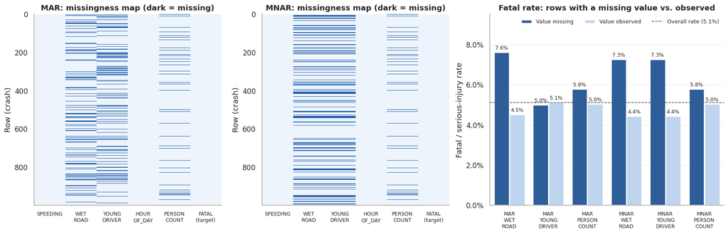

```python
fig, axes = plt.subplots(1, 3, figsize=(16, 5.2), gridspec_kw={"width_ratios": [1, 1, 1.25]})
for ax, m in zip(axes[:2], MECHS):
    ax.imshow(raw[m].isna().values, aspect="auto", interpolation="nearest",
              cmap=plt.matplotlib.colors.ListedColormap(["#eef4fc", "#1c5cab"]))
    ax.set_xticks(range(len(COLS)), ["FATAL\n(target)" if c == TARGET else c.replace("_", "\n", 1) for c in COLS], fontsize=8)
    ax.set_ylabel("Row (crash)"); ax.grid(False)
    ax.set_title(f"{m}: missingness map (dark = missing)")

# Missingness vs. the target: is the fatal rate different when a value is missing?
rows = []
for m in MECHS:
    for c in ["WET_ROAD", "YOUNG_DRIVER", "PERSON_COUNT"]:
        miss = raw[m][c].isna()
        rows += [{"mech": m, "var": c, "status": "Value missing", "rate": raw[m].loc[miss, TARGET].mean()},
                 {"mech": m, "var": c, "status": "Value observed", "rate": raw[m].loc[~miss, TARGET].mean()}]
mr = pd.DataFrame(rows); mr["label"] = mr["mech"] + "\n" + mr["var"].str.replace("_", "\n", n=1)
ax = axes[2]
sns.barplot(data=mr, x="label", y="rate", hue="status", palette=["#1c5cab", "#b7d3f6"], ax=ax,
            edgecolor="white", linewidth=2)
for cont in ax.containers:
    ax.bar_label(cont, fmt=lambda v: f"{v:.1%}", fontsize=8, padding=2)
ax.axhline(raw["MAR"][TARGET].mean(), color="#52514e", lw=1, ls="--", label="Overall rate (5.1%)")
ax.yaxis.set_major_formatter(mtick.PercentFormatter(1)); ax.set_xlabel(""); ax.set_ylabel("Fatal / serious-injury rate")
ax.set_title("Fatal rate: rows with a missing value vs. observed"); ax.set_ylim(0, 0.095)
ax.legend(title="", frameon=False, ncol=3, loc="upper right", fontsize=8.5)
ax.tick_params(axis="x", labelsize=8)
plt.tight_layout(); plt.show()
```

```python
# Which combinations of columns go missing together?
def patterns(df):
    p = df[["WET_ROAD", "YOUNG_DRIVER", "PERSON_COUNT"]].isna()
    return p.apply(lambda r: " + ".join(c for c in p.columns if r[c]) or "(complete)", axis=1).value_counts()

pat = pd.concat({m: patterns(raw[m]) for m in MECHS}, axis=1).fillna(0).astype(int)
pat.index.name = "Missing-value pattern"
pat.style.background_gradient(cmap="Blues", subset=pd.IndexSlice[pat.index != "(complete)", :]).set_caption("Rows per missing-value pattern")
```

Rows per missing-value pattern

| Missing-value pattern | MAR | MNAR |
| --- | --- | --- |
| (complete) | 615 | 707 |
| YOUNG_DRIVER | 144 | 0 |
| WET_ROAD | 132 | 0 |
| PERSON_COUNT | 45 | 59 |
| WET_ROAD + YOUNG_DRIVER | 40 | 224 |
| YOUNG_DRIVER + PERSON_COUNT | 12 | 0 |
| WET_ROAD + PERSON_COUNT | 8 | 0 |
| WET_ROAD + YOUNG_DRIVER + PERSON_COUNT | 4 | 10 |

### Direct MNAR check: are the hidden values different from the observed ones?

MNAR means that whether a value is missing depends on **the hidden value itself**. Normally that can't be tested, because the hidden values are unknown. Here the reference (section 1a) shows us what was hidden, so we can test it directly with two checks:

- **Raw gap:** compare the true values in hidden cells with the values in observed cells. The p-value comes from Fisher's exact test for the 0/1 flags and a Mann–Whitney test for `PERSON_COUNT`.
- **Conditional test:** a logistic regression of *is this cell missing?* on the cell's true value, **controlling for the always-observed variables** (`SPEEDING`, `HOUR_OF_DAY` and the target). Under MAR, missingness can depend on observed variables but not on the hidden value, so the true value should have no effect once those are controlled for. A significant effect points to MNAR.

```python
from scipy.stats import fisher_exact, mannwhitneyu

ALWAYS_OBSERVED = ["SPEEDING", "HOUR_OF_DAY", TARGET]
rows = []
for m in MECHS:
    for c in ["WET_ROAD", "YOUNG_DRIVER", "PERSON_COUNT"]:
        miss = raw[m][c].isna()
        tv = reference[c]
        if c in BINARY:
            h, o = int(tv[miss].sum()), int(tv[~miss].sum())
            p_raw = fisher_exact([[h, miss.sum() - h], [o, (~miss).sum() - o]])[1]
        else:
            p_raw = mannwhitneyu(tv[miss], tv[~miss])[1]
        X = sm.add_constant(pd.concat([tv, raw[m][ALWAYS_OBSERVED]], axis=1).astype(float))
        p_cond = sm.Logit(miss.astype(float), X).fit(disp=0).pvalues[c]
        rows.append({"Dataset": m, "Variable": c, "Hidden cells": int(miss.sum()),
                     "True mean where HIDDEN": tv[miss].mean(), "Mean where OBSERVED": tv[~miss].mean(),
                     "p (raw gap)": p_raw, "p (controlling for observed vars)": p_cond})
hid = pd.DataFrame(rows).set_index(["Dataset", "Variable"])
hid.insert(3, "Gap (hidden − observed)", hid["True mean where HIDDEN"] - hid["Mean where OBSERVED"])

def shade_p(v):
    return ("background-color: #f4c7c3; font-weight: bold" if v < 0.05 else
            "background-color: #fbe5d6" if v < 0.10 else "")

(hid.style.format({"True mean where HIDDEN": "{:.3f}", "Mean where OBSERVED": "{:.3f}",
                   "Gap (hidden − observed)": "{:+.3f}", "p (raw gap)": "{:.3f}",
                   "p (controlling for observed vars)": "{:.3f}"})
    .background_gradient(cmap="RdBu_r", subset=["Gap (hidden − observed)"], vmin=-0.06, vmax=0.06)
    .map(shade_p, subset=["p (raw gap)", "p (controlling for observed vars)"])
    .set_caption("Hidden vs. observed values (p-value shading: red = below 0.05, light = below 0.10)"))
```

Hidden vs. observed values (p-value shading: red = below 0.05, light = below 0.10)

| Dataset | Variable | Hidden cells | True mean where HIDDEN | Mean where OBSERVED | Gap (hidden − observed) | p (raw gap) | p (controlling for observed vars) |
| --- | --- | --- | --- | --- | --- | --- | --- |
| MAR | WET_ROAD | 184 | 0.152 | 0.143 | +0.009 | 0.729 | 0.765 |
|  | YOUNG_DRIVER | 200 | 0.160 | 0.180 | -0.020 | 0.535 | 0.502 |
|  | PERSON_COUNT | 69 | 2.681 | 2.344 | +0.337 | 0.062 | 0.293 |
| MNAR | WET_ROAD | 234 | 0.184 | 0.133 | +0.051 | 0.057 | 0.051 |
|  | YOUNG_DRIVER | 234 | 0.145 | 0.185 | -0.040 | 0.171 | 0.169 |
|  | PERSON_COUNT | 69 | 2.681 | 2.344 | +0.337 | 0.062 | 0.293 |

**How to read this:** under MAR, both p-values should be large. Under MNAR, the conditional p-value should be small for at least one variable.

- **MAR:** the hidden values look like the observed ones, and the hidden value does not predict missingness (every conditional p-value is 0.29 or higher). This is consistent with MAR.
- **MNAR:** wet roads were about 40% more common among hidden cells (18.4% vs. 13.3%), and that effect holds after controlling for the observed variables (p ≈ 0.05). `YOUNG_DRIVER` points the expected direction (hidden rows had fewer young drivers) but is not significant (p ≈ 0.17).
- **`PERSON_COUNT`** (identical in both files): the hidden crashes involved more people (raw p ≈ 0.06), but the effect largely disappears once observed variables are controlled for (p ≈ 0.29). That looks more like MAR than MNAR.

**Bottom line:** this check supports the MNAR label for the MNAR file, mainly through `WET_ROAD`, but the evidence is **borderline, not conclusive**. With 1,000 rows and rare outcomes, the signal sits at the edge of statistical significance.

**Data-quality findings**

- **SPEEDING, HOUR_OF_DAY and the target are complete** in both files. Missingness hits only `WET_ROAD`, `YOUNG_DRIVER` and `PERSON_COUNT`.
- **PERSON_COUNT** is missing in exactly the same 69 rows (6.9%) in both files, so this part of the problem is identical across the two datasets.
- **MAR:** `WET_ROAD` (18.4%) and `YOUNG_DRIVER` (20.0%) are missing mostly in *different* rows, so 38.5% of rows have at least one gap. The hidden true values are close to the observed ones (wet roads 15.2% hidden vs. 14.3% observed). However, rows with `WET_ROAD` missing have a higher fatal rate (7.6% vs. 4.5%, p ≈ 0.10). That is allowed under MAR, because missingness may depend on a variable we *do* observe (here, the target). It still means that dropping those rows will remove fatal crashes.
- **MNAR:** `WET_ROAD` and `YOUNG_DRIVER` are missing together in the *same* 234 rows (23.4%). The hidden rows contain **more wet roads** (18.4% vs. 13.3%) and **fewer young drivers** (14.5% vs. 18.5%) than the observed rows, and they have a **higher fatal/serious-injury rate** (7.3% vs. 4.4%, p ≈ 0.09). This is the MNAR pattern: whether a value gets recorded depends on the value itself. The evidence is clearest for `WET_ROAD` (p ≈ 0.05 after controlling for observed variables) and weaker for `YOUNG_DRIVER`. To the extent this holds, the observed data is a biased sample, and no treatment that only uses the observed values can correct for it.
- **The `PERSON_COUNT` gaps are not completely random either.** Crashes with a missing person count actually involved *more* people (true mean 2.68 vs. 2.34 observed). This is mostly explained by observed variables, though, so it behaves more like MAR.
- **Duplicates:** with only 6 low-cardinality columns, many rows are identical by design (531 duplicated 6-column rows), which is not an error. In the 80-column `features.xls`, however, 25 rows are exact duplicates, and some crashes appear 2–3 times (e.g. rows 160–162, rows 524–525) with only `SPEED_LIMIT` differing. These look like one crash repeated per road segment or unit. It is worth confirming with the data owner, since repeated rows inflate the effective sample size.

## 3. Outlier check

The binary variables can only be 0/1 (verified below), so outliers can only occur in `HOUR_OF_DAY` and `PERSON_COUNT`.

```python
df0 = raw["MAR"]
for c in BINARY:
    assert set(df0[c].dropna().unique()) <= {0, 1}, c
print("All binary columns contain only 0/1 ✓;  HOUR_OF_DAY range:", df0.HOUR_OF_DAY.min(), "–", df0.HOUR_OF_DAY.max())

def iqr_outliers(s):
    q1, q3 = s.quantile([.25, .75]); iqr = q3 - q1
    lo, hi = q1 - 1.5 * iqr, q3 + 1.5 * iqr
    z = (s - s.mean()) / s.std()
    return pd.Series({"Q1": q1, "Q3": q3, "Lower fence": lo, "Upper fence": hi,
                      "# below": int((s < lo).sum()), "# above": int((s > hi).sum()),
                      "# |z| > 3": int((z.abs() > 3).sum()), "Max": s.max()})

pd.DataFrame({c: iqr_outliers(df0[c].dropna()) for c in ["HOUR_OF_DAY", "PERSON_COUNT"]}).T
```

```
All binary columns contain only 0/1 ✓;  HOUR_OF_DAY range: 0 – 23
```

|  | Q1 | Q3 | Lower fence | Upper fence | # below | # above | # \|z\| > 3 | Max |
| --- | --- | --- | --- | --- | --- | --- | --- | --- |
| HOUR_OF_DAY | 10.0 | 18.0 | -2.0 | 30.0 | 0.0 | 0.0 | 0.0 | 23.0 |
| PERSON_COUNT | 1.0 | 3.0 | -2.0 | 6.0 | 0.0 | 10.0 | 2.0 | 48.0 |

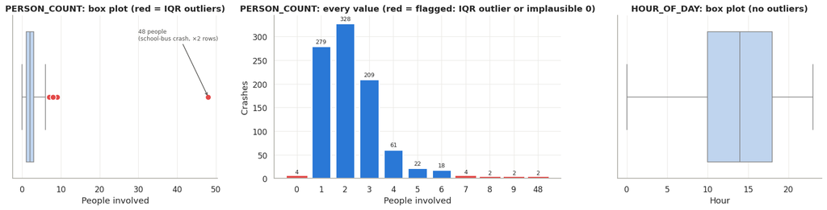

```
     PERSON_COUNT  BUS_COUNT  SCHOOL_BUS  TOTAL_UNITS  HOUR_OF_DAY  \
160           0.0        0.0         0.0          1.0         22.0
161           0.0        0.0         0.0          1.0         22.0
162           0.0        0.0         0.0          1.0         22.0
316           0.0        0.0         0.0          1.0          2.0
524          48.0        1.0         1.0          2.0         16.0
525          48.0        1.0         1.0          2.0         16.0

     FATAL_OR_SUSP_SERIOUS_INJ
160                        0.0
161                        0.0
162                        0.0
316                        0.0
524                        0.0
525                        0.0
```

```python
fig, axes = plt.subplots(1, 3, figsize=(16, 4.2), gridspec_kw={"width_ratios": [1, 1.4, 1]})
pc = df0["PERSON_COUNT"].dropna()
sns.boxplot(x=pc, ax=axes[0], color="#b7d3f6", linewidth=1, flierprops=dict(marker="o", markersize=8,
            markerfacecolor="#e34948", markeredgecolor="white"))
axes[0].set_title("PERSON_COUNT: box plot (red = IQR outliers)"); axes[0].set_xlabel("People involved")
axes[0].annotate("48 people\n(school-bus crash, ×2 rows)", xy=(48, 0), xytext=(30, -0.35),
                 arrowprops=dict(arrowstyle="->", color="#52514e"), fontsize=8, color="#52514e")

vc = pc.value_counts().sort_index()
axes[1].bar(vc.index.astype(int).astype(str), vc.values, color="#2a78d6", edgecolor="white", linewidth=2)
axes[1].bar_label(axes[1].containers[0], fontsize=8, padding=2)
axes[1].set_title("PERSON_COUNT: every value (red = flagged: IQR outlier or implausible 0)"); axes[1].set_xlabel("People involved"); axes[1].set_ylabel("Crashes")
for i, lbl in enumerate(vc.index):
    if lbl == 0 or lbl > 6:
        axes[1].patches[i].set_color("#e34948")

sns.boxplot(x=df0["HOUR_OF_DAY"], ax=axes[2], color="#b7d3f6", linewidth=1)
axes[2].set_title("HOUR_OF_DAY: box plot (no outliers)"); axes[2].set_xlabel("Hour")
plt.tight_layout(); plt.show()

print(features.loc[df0.PERSON_COUNT.isin([0, 48])].join(
    pd.read_excel(DATA_DIR / "features.xls").dropna(how="all").reset_index(drop=True)[["BUS_COUNT", "SCHOOL_BUS", "TOTAL_UNITS"]]
)[["PERSON_COUNT", "BUS_COUNT", "SCHOOL_BUS", "TOTAL_UNITS", "HOUR_OF_DAY", TARGET]])
```

**Outlier findings**

- **`PERSON_COUNT = 48` (rows 524–525).** This is a genuine extreme: `features.xls` shows the crash involved a **school bus**. It is not a data-entry error, so we **keep it**. It does pull the mean upward (mean ≈ 2.34 vs. median 2), which matters for mean imputation.
- **`PERSON_COUNT` of 7–9** are flagged by the IQR rule (fence = 6), but they are plausible multi-occupant crashes. We keep them.
- **`PERSON_COUNT = 0` (4 rows: 160–162, 316) is suspicious.** Every reportable crash involves at least one driver. These are probably hit-and-run or unknown-occupant records, and they are also among the duplicated rows noted above. We flag them and keep them so that every treatment starts from the same data.
- **`HOUR_OF_DAY`:** all values fall in 0–23 and there are no outliers. (Treating hour as a linear number ignores that 23:00 and 00:00 are adjacent. We keep it numeric because the assignment defines it that way.)
- **`SPEEDING`** is rare (3.2%) but that is a real class imbalance, not an outlier.

## 4. Apply the missing-data treatments

For each mechanism we create three new datasets:

| Treatment | What it does | Side effect to watch for |
| --- | --- | --- |
| **Mean** | Replace each missing value with the column mean | Binary columns get fractional values (e.g. 0.14), and variance shrinks |
| **Median** | Replace each missing value with the column median | Binary columns: the median is 0, so every gap becomes "No" |
| **Complete case** | Drop any row with a missing value | Loses rows; biased when missingness depends on the values (MNAR) |

All 8 datasets (original plus three treatments, for each mechanism) are also saved as CSV in `treated_datasets/`.

```python
def treat(df, how):
    if how == "Original":      return df.copy()
    if how == "Mean":          return df.fillna(df.mean())
    if how == "Median":        return df.fillna(df.median())
    if how == "Complete case": return df.dropna().reset_index(drop=True)

datasets = {(m, t): treat(raw[m], t) for m in MECHS for t in TREATMENTS}
for (m, t), d in datasets.items():
    d.to_csv(OUT_DIR / f"{m}_{t.lower().replace(' ', '_')}.csv", index=False)

fill_values = pd.DataFrame({(m, s): getattr(raw[m][["WET_ROAD", "YOUNG_DRIVER", "PERSON_COUNT"]], s)()
                            for m in MECHS for s in ["mean", "median"]}).T
fill_values.index.names = ["Dataset", "Statistic"]
display(fill_values.style.format("{:.3f}").set_caption("Values used to fill the gaps"))

inventory = pd.DataFrame([{"Dataset": m, "Treatment": t, "Rows": len(d), "Rows lost": 1000 - len(d),
                           "Missing cells": int(d.isna().sum().sum()),
                           "Fatal cases (n)": int(d[TARGET].sum()), "Fatal rate": d[TARGET].mean()}
                          for (m, t), d in datasets.items()]
                         + [{"Dataset": "Reference", "Treatment": "best-available truth", "Rows": len(reference),
                             "Rows lost": 1000 - len(reference), "Missing cells": 0,
                             "Fatal cases (n)": int(reference[TARGET].sum()), "Fatal rate": reference[TARGET].mean()}])
(inventory.style.format({"Fatal rate": "{:.2%}"}).hide(axis="index")
   .bar(subset=["Rows"], color="#b7d3f6", vmin=0, vmax=1000)
   .background_gradient(cmap="Reds", subset=["Rows lost"], vmin=0, vmax=400)
   .set_caption("All datasets at a glance"))
```

Values used to fill the gaps

| Dataset | Statistic | WET_ROAD | YOUNG_DRIVER | PERSON_COUNT |
| --- | --- | --- | --- | --- |
| MAR | mean | 0.143 | 0.180 | 2.344 |
|  | median | 0.000 | 0.000 | 2.000 |
| MNAR | mean | 0.133 | 0.185 | 2.344 |
|  | median | 0.000 | 0.000 | 2.000 |

All datasets at a glance

| Dataset | Treatment | Rows | Rows lost | Missing cells | Fatal cases (n) | Fatal rate |
| --- | --- | --- | --- | --- | --- | --- |
| MAR | Original | 1000 | 0 | 453 | 51 | 5.10% |
| MAR | Mean | 1000 | 0 | 0 | 51 | 5.10% |
| MAR | Median | 1000 | 0 | 0 | 51 | 5.10% |
| MAR | Complete case | 615 | 385 | 0 | 28 | 4.55% |
| MNAR | Original | 1000 | 0 | 537 | 51 | 5.10% |
| MNAR | Mean | 1000 | 0 | 0 | 51 | 5.10% |
| MNAR | Median | 1000 | 0 | 0 | 51 | 5.10% |
| MNAR | Complete case | 707 | 293 | 0 | 31 | 4.38% |
| Reference | best-available truth | 1000 | 0 | 0 | 51 | 5.10% |

## 5. Side-by-side histograms: original vs. treated

Each figure covers one mechanism. **Rows are variables, columns are datasets.** The y-axis is the *share of rows*, so a column with fewer rows (complete case) stays comparable, and every row of panels shares one y-scale. For the 0/1 and count variables, each distinct value gets its own bar:

- **gray “Missing” bar:** the share of rows with no value (original data only),
- **hatched bar marked `*`:** a value created by imputation that does not exist in the real data (e.g. `0.14*` = 14% of a "yes"),
- **black ◆:** the reference (best-available truth) share for that value, so you can see which treatment lands closest.

```python
def _key(v, cap):
    if pd.isna(v): return "Missing"
    if cap is not None and v > cap: return f">{cap}"
    return str(int(v)) if float(v).is_integer() else f"{v:.2f}*"

def _order(k):
    if k == "Missing": return (3, 0)
    if k.startswith(">"): return (2, 0)
    return (1, float(k.rstrip("*")))

def shares(s, cap=None):
    out = s.map(lambda v: _key(v, cap)).value_counts(normalize=True)
    return out

def hist_grid(mech, cap=10):
    cols = [(t, datasets[(mech, t)]) for t in TREATMENTS]
    fig, axes = plt.subplots(len(COLS), len(cols), figsize=(17, 3.0 * len(COLS)), sharey="row")
    for r, var in enumerate([TARGET] + PREDICTORS):
        if var == "HOUR_OF_DAY":
            ref = reference[var].value_counts(normalize=True).sort_index()
            for c, (t, d) in enumerate(cols):
                ax = axes[r, c]
                ax.hist(d[var].dropna(), bins=np.arange(-0.5, 24.5), weights=np.full(d[var].notna().sum(), 1 / len(d)),
                        color=COLORS[t], edgecolor="white", linewidth=1)
                ax.plot(ref.index, ref.values, color=COLORS["Reference"], lw=1.2, marker="D", ms=2.5, label="Reference")
                ax.set_xticks(range(0, 24, 3))
        else:
            k = None if var in BINARY else cap
            sh = {t: shares(d[var], k) for t, d in cols}
            ref = shares(reference[var], k)
            cats = sorted(set().union(*[s.index for s in sh.values()], ref.index), key=_order)
            for c, (t, d) in enumerate(cols):
                ax = axes[r, c]
                vals = sh[t].reindex(cats, fill_value=0)
                for i, (cat, v) in enumerate(vals.items()):
                    is_missing, is_imputed = cat == "Missing", cat.endswith("*")
                    ax.bar(i, v, width=0.8, color=MISSING_COLOR if is_missing else COLORS[t],
                           hatch="///" if is_imputed else None, edgecolor="white", linewidth=1.5)
                    if v > 0 and (var in BINARY or v >= 0.04):
                        ax.text(i, v, f"{v:.1%}", ha="center", va="bottom", fontsize=7.5, color="#52514e")
                rv = ref.reindex(cats)
                ax.scatter(range(len(cats)), rv.values, marker="D", s=22, color=COLORS["Reference"], zorder=5,
                           edgecolor="white", linewidth=0.8, label="Reference")
                ax.set_xticks(range(len(cats)), cats, fontsize=8)
        for c, (t, d) in enumerate(cols):
            ax = axes[r, c]
            ax.yaxis.set_major_formatter(mtick.PercentFormatter(1, decimals=0))
            ax.grid(axis="x", visible=False)
            if r == 0:
                ax.set_title(f"{t}\n(n = {len(d):,})", fontsize=12, color=COLORS[t] if t != "Original" else "#52514e")
        axes[r, 0].set_ylabel(var.replace("_", " ").replace("FATAL OR SUSP SERIOUS INJ", "FATAL/SERIOUS INJ\n(target)"),
                              fontsize=9.5, fontweight="semibold")
    axes[0, -1].legend(loc="upper right", frameon=False, fontsize=8)
    fig.suptitle(f"{mech} dataset: distribution of every variable, original vs. each treatment", fontsize=15, y=1.0)
    plt.tight_layout(); plt.show()
```

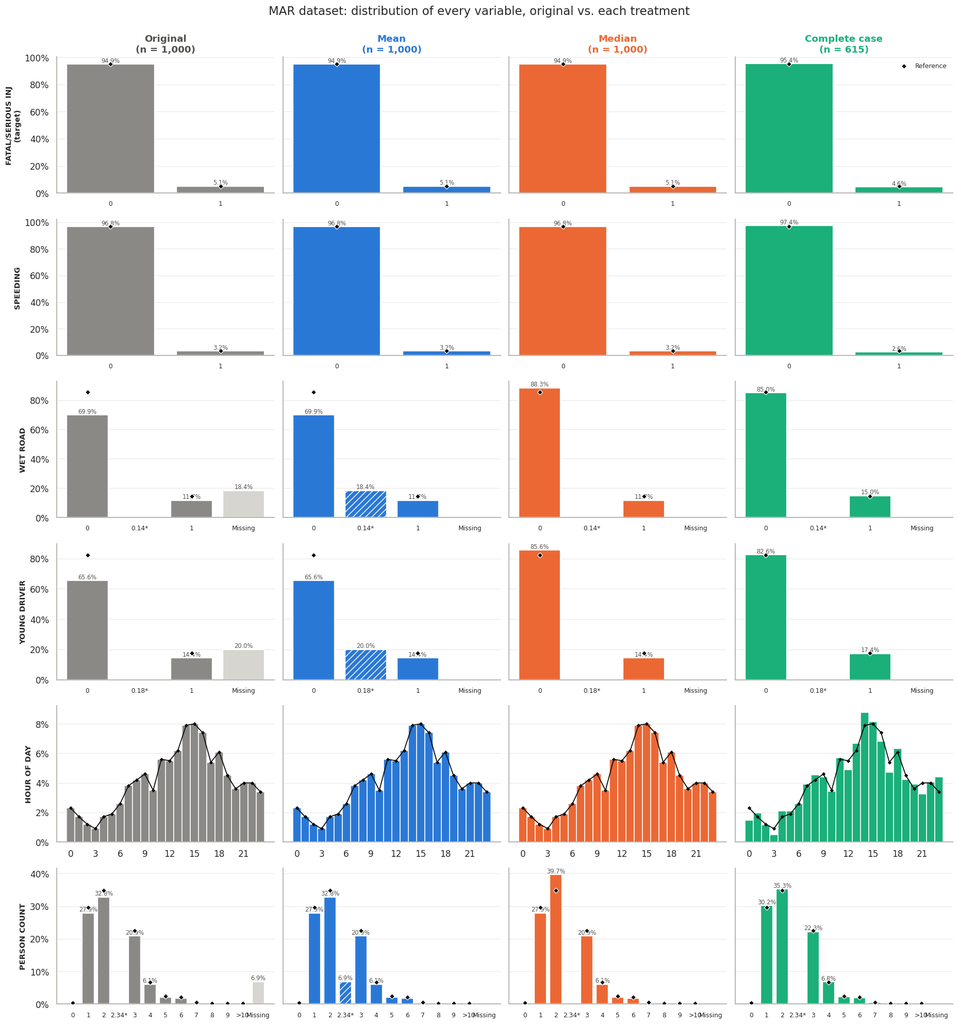

```python
hist_grid("MAR")
```

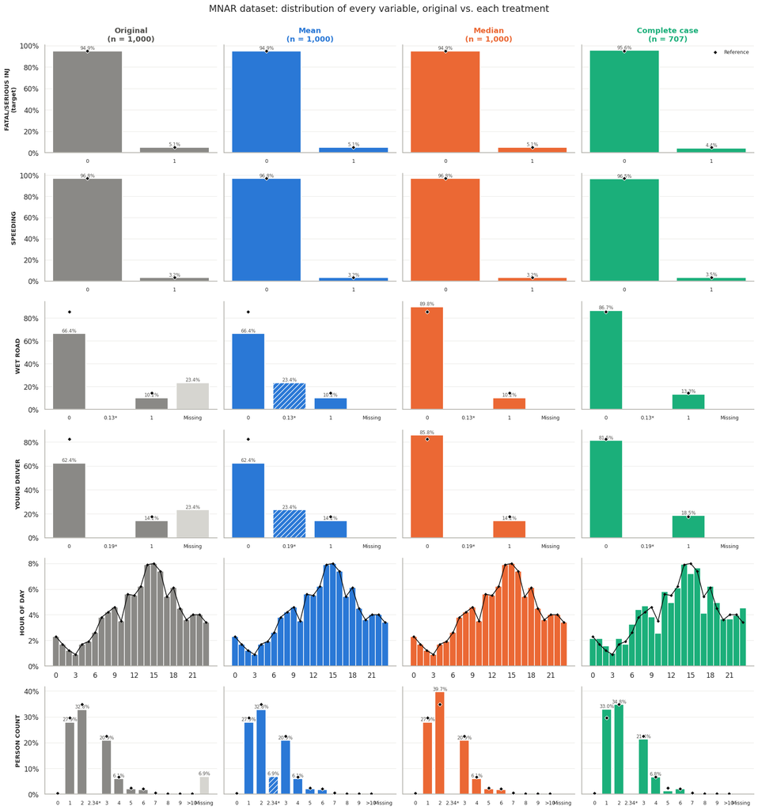

```python
hist_grid("MNAR")
```

### 5a. The same comparison as one table: how far does each dataset sit from the truth?

Each cell shows the variable's **mean** (for a 0/1 variable, the share of "yes"). The color shows the **difference from the reference**: red = too high, blue = too low, white = unbiased. For the original data, means are computed over the observed values only.

```python
rows = []
for (m, t), d in datasets.items():
    rows.append({"Dataset": m, "Treatment": t, **d[COLS].mean().to_dict()})
means = pd.DataFrame(rows).set_index(["Dataset", "Treatment"])
means.loc[("Reference", "best-available truth"), :] = ref_means
delta = means - ref_means

def color_by_delta(_):
    styles = pd.DataFrame("", index=means.index, columns=means.columns)
    for c in means.columns:
        scale = max(abs(delta[c]).max(), 1e-9)
        for i in means.index:
            x = delta.loc[i, c] / scale
            rgb = plt.cm.RdBu_r(0.5 + 0.45 * x)
            styles.loc[i, c] = f"background-color: rgba({int(rgb[0]*255)},{int(rgb[1]*255)},{int(rgb[2]*255)},0.85)"
    return styles

(means.style.apply(color_by_delta, axis=None)
      .format("{:.3f}").format("{:.2f}", subset=["HOUR_OF_DAY", "PERSON_COUNT"])
      .set_caption("Variable means by dataset (color = bias vs. reference)"))
```

Variable means by dataset (color = bias vs. reference)

| Dataset | Treatment | SPEEDING | WET_ROAD | YOUNG_DRIVER | HOUR_OF_DAY | PERSON_COUNT | FATAL_OR_SUSP_SERIOUS_INJ |
| --- | --- | --- | --- | --- | --- | --- | --- |
| MAR | Original | 0.032 | 0.143 | 0.180 | 13.42 | 2.34 | 0.051 |
|  | Mean | 0.032 | 0.143 | 0.180 | 13.42 | 2.34 | 0.051 |
|  | Median | 0.032 | 0.117 | 0.144 | 13.42 | 2.32 | 0.051 |
|  | Complete case | 0.026 | 0.150 | 0.174 | 13.51 | 2.31 | 0.046 |
| MNAR | Original | 0.032 | 0.133 | 0.185 | 13.42 | 2.34 | 0.051 |
|  | Mean | 0.032 | 0.133 | 0.185 | 13.42 | 2.34 | 0.051 |
|  | Median | 0.032 | 0.102 | 0.142 | 13.42 | 2.32 | 0.051 |
|  | Complete case | 0.035 | 0.133 | 0.185 | 13.34 | 2.17 | 0.044 |
| Reference | best-available truth | 0.032 | 0.145 | 0.176 | 13.42 | 2.37 | 0.051 |

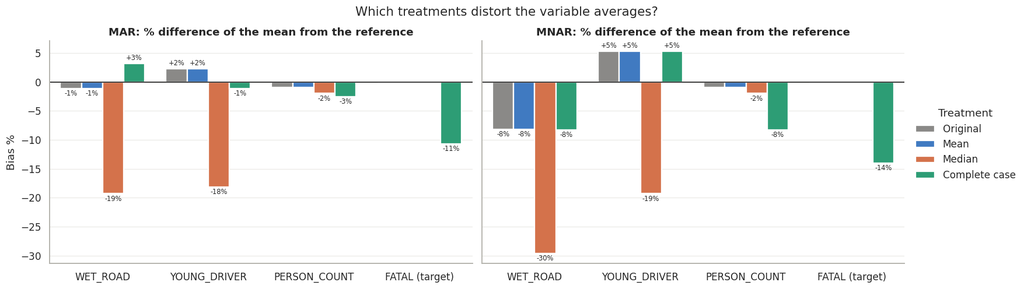

```python
# Relative bias (% difference from reference) on one chart
rel = (delta.drop(("Reference", "best-available truth")) / ref_means * 100).reset_index()
rel = rel.melt(id_vars=["Dataset", "Treatment"], var_name="Variable", value_name="Bias %")
rel = rel[rel.Variable.isin(["WET_ROAD", "YOUNG_DRIVER", "PERSON_COUNT", TARGET])]
rel["Variable"] = rel["Variable"].replace({TARGET: "FATAL (target)"})

g = sns.catplot(data=rel, kind="bar", x="Variable", y="Bias %", hue="Treatment", col="Dataset",
                palette=COLORS, hue_order=TREATMENTS, height=4.5, aspect=1.6, edgecolor="white", linewidth=1.5)
for ax in g.axes.flat:
    ax.axhline(0, color="#0b0b0b", lw=1)
    for cont in ax.containers:
        ax.bar_label(cont, fmt=lambda v: f"{v:+.0f}%" if abs(v) >= 1 else "", fontsize=7.5, padding=2)
    ax.set_xlabel("")
g.set_titles("{col_name}: % difference of the mean from the reference")
g.figure.suptitle("Which treatments distort the variable averages?", y=1.04, fontsize=14)
plt.show()
```

## 6. Logistic regression on every dataset

**Setup**

- Model: `FATAL_OR_SUSP_SERIOUS_INJ ~ SPEEDING + WET_ROAD + YOUNG_DRIVER + HOUR_OF_DAY + PERSON_COUNT`, with standardized inputs.
- **Class imbalance:** only 5.1% of crashes are fatal/serious. An ordinary logistic regression simply predicts "no" every time. That scores ~95% accuracy but an **F1 of 0** (demonstrated below). We therefore use `class_weight="balanced"`, which makes the model actually try to find the fatal crashes. Accuracy then falls below 95%, and that is expected.
- **Evaluation:** stratified 5-fold cross-validation repeated 20 times (100 fits per dataset). We report the mean ± standard deviation, because with only ~50 positive cases a single train/test split would be very noisy.
- **The "Original" datasets** cannot be passed to a logistic regression with gaps in them. Standard software (R `glm`, `statsmodels`) silently drops incomplete rows, so modeling the original data *is* complete-case analysis. The original is therefore represented by the complete-case model, and we add the **Reference** model as the benchmark.

```python
CV = RepeatedStratifiedKFold(n_splits=5, n_repeats=20, random_state=42)
SCORING = {"Accuracy": "accuracy", "F1": "f1", "Recall": "recall", "Precision": "precision", "ROC AUC": "roc_auc"}
MODEL_SETS = [(m, t) for m in MECHS for t in ["Mean", "Median", "Complete case"]]

def model(weighted=True):
    return make_pipeline(StandardScaler(), LogisticRegression(class_weight="balanced" if weighted else None, max_iter=2000))

# Why class weighting is necessary
d = reference
r = cross_validate(model(weighted=False), d[PREDICTORS], d[TARGET], cv=CV, scoring=SCORING)
print("Un-weighted model on the reference data:  "
      f"accuracy = {r['test_Accuracy'].mean():.3f},  F1 = {r['test_F1'].mean():.3f},  recall = {r['test_Recall'].mean():.3f}"
      "\n→ it predicts 'not fatal' for everyone, so we use class_weight='balanced' from here on.")
```

```
Un-weighted model on the reference data:  accuracy = 0.949,  F1 = 0.000,  recall = 0.000
→ it predicts 'not fatal' for everyone, so we use class_weight='balanced' from here on.
```

```python
results = []
model_data = {(m, t): datasets[(m, t)] for m, t in MODEL_SETS}
model_data[("Reference", "Reference")] = reference
for (m, t), d in model_data.items():
    r = cross_validate(model(), d[PREDICTORS], d[TARGET], cv=CV, scoring=SCORING)
    row = {"Dataset": m, "Treatment": t, "Rows": len(d), "Fatal cases": int(d[TARGET].sum())}
    for k in SCORING:
        row[k] = r[f"test_{k}"].mean(); row[f"{k} sd"] = r[f"test_{k}"].std()
    results.append(row)
results = pd.DataFrame(results)

show = results.set_index(["Dataset", "Treatment"])
fmt = {k: (lambda k: lambda _: None)(k) for k in SCORING}
tbl = pd.DataFrame({"Rows": show["Rows"], "Fatal cases": show["Fatal cases"],
                    **{k: [f"{a:.3f} ± {s:.3f}" for a, s in zip(show[k], show[f'{k} sd'])] for k in SCORING}},
                   index=show.index)
(tbl.style.apply(lambda col: [f"background-color: rgba(42,120,214,{0.12 + 0.5 * (v - show[col.name].min()) / max(show[col.name].max() - show[col.name].min(), 1e-9):.2f})"
                              for v in show[col.name]], subset=list(SCORING))
    .set_caption("Cross-validated performance (mean ± sd over 100 folds; darker = better)"))
```

Cross-validated performance (mean ± sd over 100 folds; darker = better)

| Dataset | Treatment | Rows | Fatal cases | Accuracy | F1 | Recall | Precision | ROC AUC |
| --- | --- | --- | --- | --- | --- | --- | --- | --- |
| MAR | Mean | 1000 | 51 | 0.623 ± 0.078 | 0.083 ± 0.034 | 0.338 ± 0.148 | 0.048 ± 0.020 | 0.514 ± 0.090 |
|  | Median | 1000 | 51 | 0.614 ± 0.082 | 0.085 ± 0.033 | 0.355 ± 0.154 | 0.048 ± 0.019 | 0.513 ± 0.084 |
|  | Complete case | 615 | 28 | 0.582 ± 0.085 | 0.075 ± 0.037 | 0.383 ± 0.204 | 0.042 ± 0.021 | 0.486 ± 0.095 |
| MNAR | Mean | 1000 | 51 | 0.610 ± 0.080 | 0.087 ± 0.037 | 0.369 ± 0.166 | 0.050 ± 0.021 | 0.524 ± 0.089 |
|  | Median | 1000 | 51 | 0.565 ± 0.092 | 0.096 ± 0.033 | 0.447 ± 0.164 | 0.054 ± 0.020 | 0.540 ± 0.088 |
|  | Complete case | 707 | 31 | 0.646 ± 0.060 | 0.102 ± 0.037 | 0.458 ± 0.168 | 0.058 ± 0.021 | 0.581 ± 0.103 |
| Reference | Reference | 1000 | 51 | 0.587 ± 0.093 | 0.099 ± 0.033 | 0.447 ± 0.165 | 0.056 ± 0.019 | 0.543 ± 0.092 |

```python
# Interactive comparison: hover any bar for the exact value
metrics = ["Accuracy", "F1", "ROC AUC", "Recall"]
fig = make_subplots(rows=1, cols=len(metrics), subplot_titles=metrics, shared_yaxes=False, horizontal_spacing=0.06)
for t in ["Mean", "Median", "Complete case", "Reference"]:
    sub = results[results.Treatment == t]
    for j, k in enumerate(metrics, 1):
        fig.add_trace(go.Bar(x=sub.Dataset, y=sub[k], name=t, legendgroup=t, showlegend=(j == 1),
                             marker=dict(color=COLORS[t], line=dict(color="white", width=1.5)),
                             error_y=dict(type="data", array=sub[f"{k} sd"], color="#8a8986", thickness=1, width=3),
                             hovertemplate=f"<b>%{{x}} · {t}</b><br>{k}: %{{y:.3f}}<extra></extra>"),
                      row=1, col=j)
fig.update_layout(barmode="group", height=430, template="simple_white", bargap=0.25, bargroupgap=0.08,
                  title="Model performance by dataset and treatment (error bars = ±1 sd across CV folds)",
                  legend=dict(orientation="h", y=-0.15, x=0.5, xanchor="center"), margin=dict(t=80))
fig.update_yaxes(gridcolor="#ebeae6", showgrid=True)
fig.show()
```

[interactive chart not shown]

### 6a. A fair head-to-head: train on the treated data, test on the true data

The table above scores each model on *its own* (treated) data. Complete-case models are tested only on "easy" complete rows, and imputed models are tested against imputed values. To compare like with like, we also run a second evaluation. The same 1,000 rows are split into the **same folds** for every treatment. Each model is **trained on its treated training rows** (imputation statistics are computed from the training rows only, so nothing leaks), and every model is then **tested on the same held-out rows using their true reference values**. This measures what we actually care about: how well a model built on each treatment performs in the real world.

```python
y_all = reference[TARGET].values
cv_fair = RepeatedStratifiedKFold(n_splits=5, n_repeats=20, random_state=7)

fair = []
for m in MECHS:
    for t in ["Mean", "Median", "Complete case", "Reference"]:
        scores = {k: [] for k in ["Accuracy", "F1", "ROC AUC", "Recall"]}
        for tr, te in cv_fair.split(np.zeros(1000), y_all):
            train = reference.iloc[tr] if t == "Reference" else treat(raw[m].iloc[tr], t)
            test = reference.iloc[te]
            clf = model().fit(train[PREDICTORS], train[TARGET])
            p = clf.predict(test[PREDICTORS]); pr = clf.predict_proba(test[PREDICTORS])[:, 1]
            scores["Accuracy"].append(accuracy_score(test[TARGET], p))
            scores["F1"].append(f1_score(test[TARGET], p))
            scores["Recall"].append(recall_score(test[TARGET], p))
            scores["ROC AUC"].append(roc_auc_score(test[TARGET], pr))
        fair.append({"Dataset": m, "Treatment": t, **{k: np.mean(v) for k, v in scores.items()},
                     **{f"{k} sd": np.std(v) for k, v in scores.items()}})
fair = pd.DataFrame(fair)
fair_show = fair.pivot(index="Treatment", columns="Dataset", values=["Accuracy", "F1", "ROC AUC"]).reindex(["Mean", "Median", "Complete case", "Reference"])
display(fair_show.style.format("{:.3f}").background_gradient(cmap="Blues", axis=0)
   .set_caption("Tested on TRUE values of the same held-out rows (higher = better)"))
print("Typical fold-to-fold standard deviation:  F1 ≈ %.3f,  accuracy ≈ %.3f,  AUC ≈ %.3f"
      % (fair["F1 sd"].mean(), fair["Accuracy sd"].mean(), fair["ROC AUC sd"].mean()))
```

Tested on TRUE values of the same held-out rows (higher = better)

| Dataset Treatment | Accuracy MAR | Accuracy MNAR | F1 MAR | F1 MNAR | ROC AUC MAR | ROC AUC MNAR |
| --- | --- | --- | --- | --- | --- | --- |
| Mean | 0.614 | 0.585 | 0.085 | 0.092 | 0.517 | 0.536 |
| Median | 0.618 | 0.586 | 0.088 | 0.095 | 0.518 | 0.540 |
| Complete case | 0.580 | 0.639 | 0.092 | 0.099 | 0.520 | 0.541 |
| Reference | 0.590 | 0.590 | 0.098 | 0.098 | 0.540 | 0.540 |

```
Typical fold-to-fold standard deviation:  F1 ≈ 0.034,  accuracy ≈ 0.071,  AUC ≈ 0.080
```

## 7. Which missing-data method is less biased?

Accuracy and F1 tell us how well a model *predicts*. **Bias** asks whether the model learned the *right relationship*. To measure it, we fit an unpenalized logistic regression (statsmodels) on each dataset with the raw, unscaled predictors, and compare its **odds ratios** with the odds ratios from the reference data.

```python
def fit_logit(d):
    X = sm.add_constant(d[PREDICTORS].astype(float))
    res = sm.Logit(d[TARGET].astype(float), X).fit(disp=0, maxiter=200)
    ci = res.conf_int()
    return pd.DataFrame({"coef": res.params, "lo": ci[0], "hi": ci[1], "p": res.pvalues}).drop("const")

coefs = {(m, t): fit_logit(model_data[(m, t)]) for (m, t) in model_data}
ref_coef = coefs[("Reference", "Reference")]

or_tbl = pd.DataFrame({f"{m} · {t}" if m != "Reference" else "Reference": np.exp(c["coef"]) for (m, t), c in coefs.items()}).T
or_tbl.index.name = "Odds ratio for…"
(or_tbl.style.format("{:.2f}")
   .apply(lambda col: ["font-weight: bold; border-top: 2px solid #0b0b0b" if i == "Reference" else "" for i in col.index])
   .background_gradient(cmap="PuOr_r", axis=None, vmin=0.3, vmax=3.0)
   .set_caption("Odds ratios (per 1-unit change): how much each factor multiplies the odds of a fatal/serious crash"))
```

Odds ratios (per 1-unit change): how much each factor multiplies the odds of a fatal/serious crash

| Odds ratio for… | SPEEDING | WET_ROAD | YOUNG_DRIVER | HOUR_OF_DAY | PERSON_COUNT |
| --- | --- | --- | --- | --- | --- |
| MAR · Mean | 4.10 | 0.97 | 0.90 | 1.03 | 1.02 |
| MAR · Median | 4.08 | 0.83 | 0.92 | 1.03 | 1.02 |
| MAR · Complete case | 3.43 | 0.94 | 0.75 | 1.02 | 1.01 |
| MNAR · Mean | 4.10 | 0.93 | 0.76 | 1.03 | 1.02 |
| MNAR · Median | 4.14 | 0.79 | 0.63 | 1.03 | 1.02 |
| MNAR · Complete case | 7.54 | 0.77 | 0.77 | 1.06 | 1.08 |
| Reference | 4.04 | 0.66 | 0.85 | 1.03 | 1.02 |

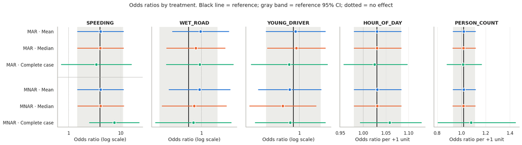

```python
# Forest plot: each treatment's odds ratio with its 95% CI, against the reference (black line)
fig, axes = plt.subplots(1, len(PREDICTORS), figsize=(18, 4.8), sharey=True)
order = [(m, t) for m in MECHS for t in ["Mean", "Median", "Complete case"]]
ylabels = [f"{m} · {t}" for m, t in order]
for ax, var in zip(axes, PREDICTORS):
    r0 = ref_coef.loc[var]
    ax.axvspan(np.exp(r0.lo), np.exp(r0.hi), color="#d6d5d0", alpha=0.45, lw=0)
    ax.axvline(np.exp(r0.coef), color=COLORS["Reference"], lw=1.6)
    ax.axvline(1, color="#8a8986", lw=0.8, ls=":")
    for i, (m, t) in enumerate(order):
        c = coefs[(m, t)].loc[var]
        y = i + (0.5 if m == "MNAR" else 0)
        ax.plot([np.exp(c.lo), np.exp(c.hi)], [y, y], color=COLORS[t], lw=2, solid_capstyle="round")
        ax.scatter(np.exp(c.coef), y, s=60, color=COLORS[t], edgecolor="white", linewidth=1.5, zorder=3)
    if var in BINARY:
        ax.set_xscale("log"); ax.set_xlabel("Odds ratio (log scale)")
        ax.xaxis.set_major_formatter(mtick.FuncFormatter(lambda v, _: f"{v:g}"))
        ax.xaxis.set_minor_formatter(mtick.NullFormatter())
    else:
        ax.set_xlabel("Odds ratio per +1 unit")
    ax.set_title(var)
    ax.grid(axis="y", visible=False)
axes[0].set_yticks([i + (0.5 if m == "MNAR" else 0) for i, (m, _) in enumerate(order)], ylabels)
axes[0].invert_yaxis()
axes[0].axhline(2.75, color="#b5b4ae", lw=0.8)
fig.suptitle("Odds ratios by treatment. Black line = reference; gray band = reference 95% CI; dotted = no effect",
             fontsize=13, y=1.03)
plt.tight_layout(); plt.show()
```

```python
# Bias scorecard: lower = closer to the truth
ref_sd = reference[PREDICTORS].std()
rows = []
for (m, t) in order:
    c = coefs[(m, t)]
    d = model_data[(m, t)]
    coef_err = (c["coef"] - ref_coef["coef"]) * ref_sd   # per-SD scale so all 5 predictors are comparable
    rows.append({"Dataset": m, "Treatment": t,
                 "Rows used": len(d),
                 "|Δ fatal rate| (pts)": abs(d[TARGET].mean() - TRUE_FATAL) * 100,
                 "|Δ WET_ROAD mean| (pts)": abs(d.WET_ROAD.mean() - ref_means.WET_ROAD) * 100,
                 "|Δ YOUNG_DRIVER mean| (pts)": abs(d.YOUNG_DRIVER.mean() - ref_means.YOUNG_DRIVER) * 100,
                 "|Δ PERSON_COUNT mean|": abs(d.PERSON_COUNT.mean() - ref_means.PERSON_COUNT),
                 "|Δ coef| SPEEDING": abs(coef_err["SPEEDING"]),
                 "|Δ coef| WET_ROAD": abs(coef_err["WET_ROAD"]),
                 "|Δ coef| YOUNG_DRIVER": abs(coef_err["YOUNG_DRIVER"]),
                 "|Δ coef| PERSON_COUNT": abs(coef_err["PERSON_COUNT"]),
                 "Coef RMSE (per-SD)": np.sqrt((coef_err ** 2).mean()),
                 "SE inflation vs ref": ((c.hi - c.lo) / (ref_coef.hi - ref_coef.lo)).mean()})
score = pd.DataFrame(rows).set_index(["Dataset", "Treatment"])
score["Rank (by coef RMSE, within dataset)"] = score.groupby(level=0)["Coef RMSE (per-SD)"].rank().astype(int)
score.columns = pd.MultiIndex.from_tuples(
    [("", c) if c == "Rows used" else ("Distribution bias", c) if "mean" in c or "rate" in c else ("Model (coefficient) bias", c)
     for c in score.columns])
(score.style.format("{:.3f}").format("{:.0f}", subset=[c for c in score.columns if c[1] in ("Rows used", "Rank (by coef RMSE, within dataset)")])
      .format("{:.2f}×", subset=[c for c in score.columns if c[1] == "SE inflation vs ref"])
      .background_gradient(cmap="Reds", subset=[c for c in score.columns if c[1].startswith("|") or "RMSE" in c[1]], axis=0)
      .set_caption("Bias scorecard vs. reference (Δ = distance from reference; lower / lighter = less biased)"))
```

Bias scorecard vs. reference (Δ = distance from reference; lower / lighter = less biased)

| Dataset | Treatment | Rows used | Distribution bias \|Δ fatal rate\| (pts) | Distribution bias \|Δ WET_ROAD mean\| (pts) | Distribution bias \|Δ YOUNG_DRIVER mean\| (pts) | Distribution bias \|Δ PERSON_COUNT mean\| | Model (coefficient) bias \|Δ coef\| SPEEDING | Model (coefficient) bias \|Δ coef\| WET_ROAD | Model (coefficient) bias \|Δ coef\| YOUNG_DRIVER | Model (coefficient) bias \|Δ coef\| PERSON_COUNT | Model (coefficient) bias Coef RMSE (per-SD) | Model (coefficient) bias SE inflation vs ref | Model (coefficient) bias Rank (by coef RMSE, within dataset) |
| --- | --- | --- | --- | --- | --- | --- | --- | --- | --- | --- | --- | --- | --- |
| MAR | Mean | 1000 | 0.000 | 0.162 | 0.400 | 0.023 | 0.003 | 0.137 | 0.023 | 0.002 | 0.062 | 1.01× | 2 |
|  | Median | 1000 | 0.000 | 2.800 | 3.200 | 0.047 | 0.002 | 0.084 | 0.030 | 0.001 | 0.040 | 1.02× | 1 |
|  | Complete case | 615 | 0.547 | 0.459 | 0.202 | 0.060 | 0.029 | 0.127 | 0.046 | 0.010 | 0.064 | 1.40× | 3 |
| MNAR | Mean | 1000 | 0.000 | 1.184 | 0.938 | 0.023 | 0.002 | 0.124 | 0.041 | 0.003 | 0.058 | 1.04× | 1 |
|  | Median | 1000 | 0.000 | 4.300 | 3.400 | 0.047 | 0.004 | 0.064 | 0.115 | 0.002 | 0.059 | 1.07× | 2 |
|  | Complete case | 707 | 0.715 | 1.204 | 0.929 | 0.196 | 0.110 | 0.055 | 0.036 | 0.143 | 0.110 | 1.64× | 3 |

```python
# One-picture summary: prediction quality (x) vs. bias (y). Bottom-right is best.
fig = go.Figure()
for (m, t) in order:
    f1 = fair[(fair.Dataset == m) & (fair.Treatment == t)]["F1"].item()
    b = score.loc[(m, t), ("Model (coefficient) bias", "Coef RMSE (per-SD)")]
    fig.add_trace(go.Scatter(x=[f1], y=[b], mode="markers+text", name=f"{m} · {t}",
                             marker=dict(size=18, color=COLORS[t], symbol="circle" if m == "MAR" else "diamond",
                                         line=dict(color="white", width=2)),
                             text=[f"{m} · {t}"], textposition="top center", textfont=dict(size=11, color="#52514e"),
                             hovertemplate=f"<b>{m} · {t}</b><br>F1 on true data: %{{x:.3f}}<br>Coefficient RMSE: %{{y:.3f}}<extra></extra>"))
fig.update_layout(template="simple_white", height=480, showlegend=False,
                  title="Prediction vs. bias (circles = MAR, diamonds = MNAR; best = bottom-right)",
                  xaxis_title="F1 when tested on true values (higher = better)",
                  yaxis_title="Coefficient error vs. reference (RMSE, lower = better)")
fig.update_xaxes(showgrid=True, gridcolor="#ebeae6"); fig.update_yaxes(showgrid=True, gridcolor="#ebeae6")
fig.show()
```

[interactive chart not shown]

## 8. Final summary

### What the data looked like

- **Two clean predictors and the target were complete**: `SPEEDING`, `HOUR_OF_DAY` and `FATAL_OR_SUSP_SERIOUS_INJ` (5.1% positive, 51 of 1,000 crashes). Missingness affects only `WET_ROAD`, `YOUNG_DRIVER` and `PERSON_COUNT`.
- **Outliers:** `PERSON_COUNT = 48` is real (a school-bus crash), so we kept it. Four crashes with `PERSON_COUNT = 0` are implausible and should be reviewed. `HOUR_OF_DAY` has no outliers. A few crash records appear to be duplicated in the source extract.
- **Because the MAR and MNAR files are the same 1,000 crashes**, we could rebuild a complete reference (best-available truth) and measure bias directly instead of guessing at it.

### Treatment by treatment

[output not shown]

### Which method is less biased?

1. **Complete-case removal is the most biased under both mechanisms**, and the problem is much worse under MNAR. Under MNAR the dropped rows differ systematically (more wet roads, more severe crashes), so deleting them shifts the fatal rate, inflates the speeding effect and widens every confidence interval. Even under MAR it lost 45% of the already rare fatal cases.
2. **Mean imputation is the least biased simple method overall.** It preserves the variable averages (exactly so under MAR) and keeps the model coefficients close to the reference.
3. **Median imputation should be avoided for binary variables.** It silently recodes every missing value as "no", which is a large distortion of the predictor distributions under both mechanisms. On model coefficients it performed about as well as mean imputation.
4. **MAR vs. MNAR:** under MAR, the simple imputations come close to the truth. Under **MNAR, every method stays biased**. A treatment that only uses the observed values cannot know that the hidden roads were wetter, so mean imputation inherits the observed-data bias and median imputation adds more on top.

### Recommendations

- **Recover the values from the source instead of imputing them.** `WET_ROAD` can be derived from `ROAD_CONDITION` (codes 08 Water and 09 Wet; 100% agreement with known flags) and `YOUNG_DRIVER` from the 16–20 driver-age counts (99.7% agreement) in `features.xls` (section 1a). That removes the missing-data problem entirely.
- If recovery is not possible: use **multiple imputation (e.g. MICE)** with auxiliary variables plus a **missingness-indicator** column, and run a **sensitivity analysis** for the MNAR case.
- Report **F1, recall and ROC AUC rather than accuracy** for this imbalanced outcome, and add stronger predictors (e.g. unbelted occupants, impairment, speed limit, pedestrian involvement) before relying on the model.